# Lecture 9 - Probability part 3: random variables, expectation

Joshua Loftus

January 31, 2018

#### Review

- Bayes’ theorem
- Switching between $P(A | B)$ and $P(B | A)$
- $P(B | A) = P(A | B)P(B)/P(A)$
- Today: probabilities related to sums, Binomial random variables, expectation(?)

##### Probabilities for sums

- Suppose we roll two 6-sided die, adding the two results, and are interested in calculating probabilities for different values of this sum
- Let’s call this value $X$
- Each dice is between 1 and 6, so the $X$ is between 2 and 12
- $P(X = 2) = P(D_1 = 1 \text{ and } D_2 = 1)$… *what’s the easy way to calculate this?*
- **Multiplication rule** – the die are independent! $P(D_1 = 1)P(D_2 = 2)$
- $P(X = 2) = (1/6)^2$ = 1/36
- What is $P(X = 12)$? (same)
- How about $P(X = 3)$? This can happen if $D_1 = 1$ and $D_2 = 2$ *or* if $D_1 = 2$ and $D_2 = 1$
- Two ways it can happen, each of those has probability 1/36… *what’s the easy way to calculate this?*
- **Addition rule** – disjoint events! $P(D_1 = 1)P(D_2 = 2) + P(D_1 = 2)P(D_2 = 1)$
- $P(X = 3) = (1/6)^2 + (1/6)^2$
- In general, to find $P(X = x)$ we count the number of ways two sides of the die can add up to $x$ and multiply that number by $(1/6)^2$
- Which outcome(s) are the most likely ones? The middle: 7 (halfway between 2 and 12)
- e.g. for 7 (1, 6), (2, 5), (3, 4), (4, 3), (5, 2), (6, 1)
- $P(X = 7) = 6(1/6)^2 = 1/6$
- Suppose we toss 4 coins and add up the number of heads, call this $X$
- $P(X = 4) = P(X = 0) = (1/2)^4$
- For $X = 2$, could be (0,0,1,1), (0,1,0,1), (0,1,1,0), (1,0,0,1), (1,0,1,0), (1,1,0,0)
- $P(X = 2) = (1/2)^4 + (1/2)^4 + (1/2)^4 + (1/2)^4 + (1/2)^4 + (1/2)^4 = 6(1/2)^4 = 3/8$
- What if we toss a coin 60 times and count the number of heads?
- e.g. for 0, every one must be tails, probability $(1/2)^{60}$. Similar for 60
- e.g. for 1, pick 1 out of 60 tosses to come up heads–this can happen in 60 ways. So $60(1/2)^{60}$
- What about 30?… math to the rescue?
- Yes! There is an easy formula. Answer: over $10^{17}$ ways!
- About 10.2% for 30, 9.9% for 31 and 29, 8.9% for 32 and 28.
- These are really large compared to $1/2^{60} \approx 0.$(16 zeros)87%
- Many calculations like this are made possible by studying random outcomes that are *numbers*
- i.e. random variables

##### Random variables, continued

- **Probability density function** $p_X(x) = P(X = x)$
- **Cumulative distribution function** $F_X(x) = P(X \leq x)$
- Bernoulli: Ber($p$), $D = \{ 0, 1 \}$ $P(X = 1) = p$. Standard: $p = 1/2$.
- Binomial: Bin($n, p$) number of “successes” in $n$ independent “trials” with each having success probability $p$
- If $p = 1/2$, like tossing a coin $n$ times and counting the tails
- Otherwise need a “biased” coin–one with probability $p \neq 1/2$ of landing on heads
- **Independent random variables** $X, Y$ are indepedent if $P(X = x \text{ and } Y = y) = P(X = x)P(Y = y) = p_X(x)p_Y(y)$
- $P(X = x \text{ and } Y = y) = p_{X,Y}(x,y)$ is called the **joint distribution** of $X$ and $Y$
- If they are independent, the joint distribution factors into the product of their individual distributions $p_{X,Y}(x,y) = p_X(x)p_Y(y)$
- Suppose we have $n$ independent Ber($p$) r.v.s and we add them
- What is the distribution of $X_1 + X_2 + \cdots + X_n$?
- Each one is 0 or 1, there are $n$ of them, they are independent…
- The sum is just the count of how many of them equal 1
- This is Bin($n, p$)!

##### Expected values of random variables

- A random variable $X$ can potentially equal many possible values, just like how a variable in a dataset might take many different values
- Can we summarize a random variable in a similar way to how we summarize data?
- What about an average value, like the mean?
- For random variables we call this the expected value
- $E[X] = \sum_{x \in D} x p_X(x)$
- Weighted sum of all the possible values, with weight given by probability of that value
- e.g. for $X \sim Ber($p$)$, what is $E[X]$?
- $0\cdot P(X = 0) + 1 \cdot P(X = 1) = 0(1-p) + 1(p) = p$

##### Generating random variables in R

Uniform integers between 0 and 10

```r
# One sample:
sample(0:10, 1)
```

```
## [1] 7
```

```r
# 10 samples:
sample(0:10, 10, replace=T)
```

```
##  [1]  7  7  3  3  2  4 10  1  7  2
```

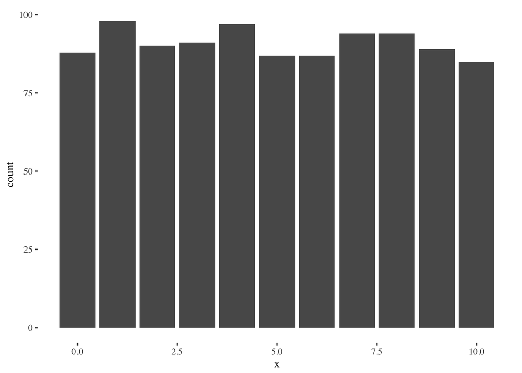

```r
# Plotting a probability histogram of 1000 samples
df <- data.frame(x = sample(0:10, 1000, replace=T))
ggplot(df, aes(x)) + stat_count() + theme_tufte()
```

Uniform continuous numbers between 0 and 1

```r
# One sample:
runif(1)
```

```
## [1] 0.5788398
```

```r
# 10 samples:
runif(10)
```

```
##  [1] 0.2869595 0.8481076 0.2533678 0.6708428 0.5025239 0.9634737 0.1871624
##  [8] 0.9848846 0.5392730 0.1547897
```

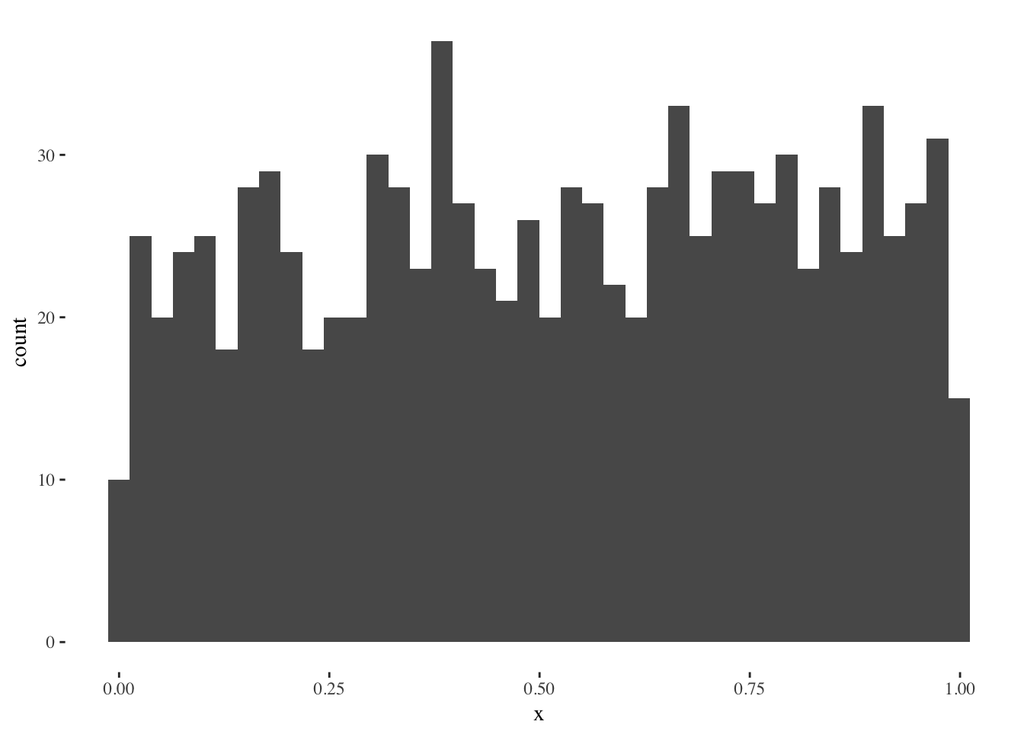

```r
# Plotting 1000 samples
df <- data.frame(x = runif(1000))
ggplot(df, aes(x)) + geom_histogram(bins = 40) + theme_tufte()
```

Binomial with 10 trials, success prob 1/2

```r
# One sample:
rbinom(1, 10, .5)
```

```
## [1] 8
```

```r
# 10 samples:
rbinom(10, 10, .5)
```

```
##  [1] 7 5 6 4 6 4 6 7 7 5
```

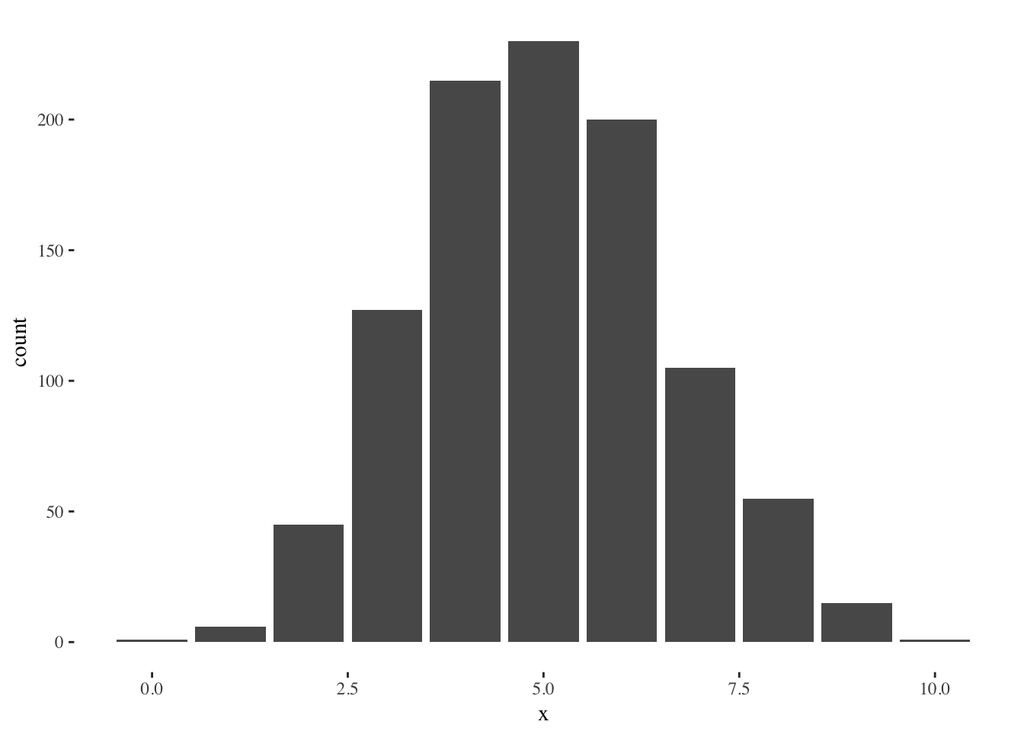

```r
# Plotting 1000 samples
df <- data.frame(x = rbinom(1000, 10, .5))
ggplot(df, aes(x)) + stat_count() + theme_tufte()
```